# Brain Tumour MRI Image Classification

## Do the same for testset and merge both dataframes

```python
image_dir = Path("E:\TGushpu\Brain Tumor MRI Classfication\Testing")
filepaths = list(image_dir.glob(r'**/*.jpg'))
labels = list(map(lambda x: os.path.split(os.path.split(x)[0])[1], filepaths))

filepaths = pd.Series(filepaths, name='Filepaths').astype(str)
labels = pd.Series(labels, name='Labels')

image_df_test = pd.concat([filepaths, labels], axis=1)
image_df_test = image_df_test[image_df_test['Labels'].apply(lambda x: x[-2:] != 'GT')]

image_df_test = image_df_test.sample(frac=1).reset_index(drop = True)
display(image_df_test.head())
print(image_df_test.shape)
print(image_df_test['Labels'].value_counts())
```

|  | Filepaths | Labels |
| --- | --- | --- |
| 0 | E:\TGushpu\Brain Tumor MRI Classfication\Testi... | no_tumor |
| 1 | E:\TGushpu\Brain Tumor MRI Classfication\Testi... | pituitary_tumor |
| 2 | E:\TGushpu\Brain Tumor MRI Classfication\Testi... | meningioma_tumor |
| 3 | E:\TGushpu\Brain Tumor MRI Classfication\Testi... | no_tumor |
| 4 | E:\TGushpu\Brain Tumor MRI Classfication\Testi... | no_tumor |

```
(394, 2)
Labels
meningioma_tumor    115
no_tumor            105
glioma_tumor        100
pituitary_tumor      74
Name: count, dtype: int64
```

- The same process is repeated for the testing dataset, creating another DataFrame (image_df_test).

## Both DataFrames are then concatenated to create a single DataFrame (df) containing the entire dataset.

```python
df = pd.concat([image_df_train, image_df_test], axis=0)
df = df.reset_index(drop = True)
display(df.head())
print(df.shape)
print(df['Labels'].value_counts())
```

|  | Filepaths | Labels |
| --- | --- | --- |
| 0 | E:\TGushpu\Brain Tumor MRI Classfication\Train... | pituitary_tumor |
| 1 | E:\TGushpu\Brain Tumor MRI Classfication\Train... | meningioma_tumor |
| 2 | E:\TGushpu\Brain Tumor MRI Classfication\Train... | no_tumor |
| 3 | E:\TGushpu\Brain Tumor MRI Classfication\Testi... | meningioma_tumor |
| 4 | E:\TGushpu\Brain Tumor MRI Classfication\Train... | glioma_tumor |

```
(3837, 2)
Labels
meningioma_tumor    1105
glioma_tumor        1078
pituitary_tumor     1011
no_tumor             643
Name: count, dtype: int64
```

# Displaying a subsample of the dataset

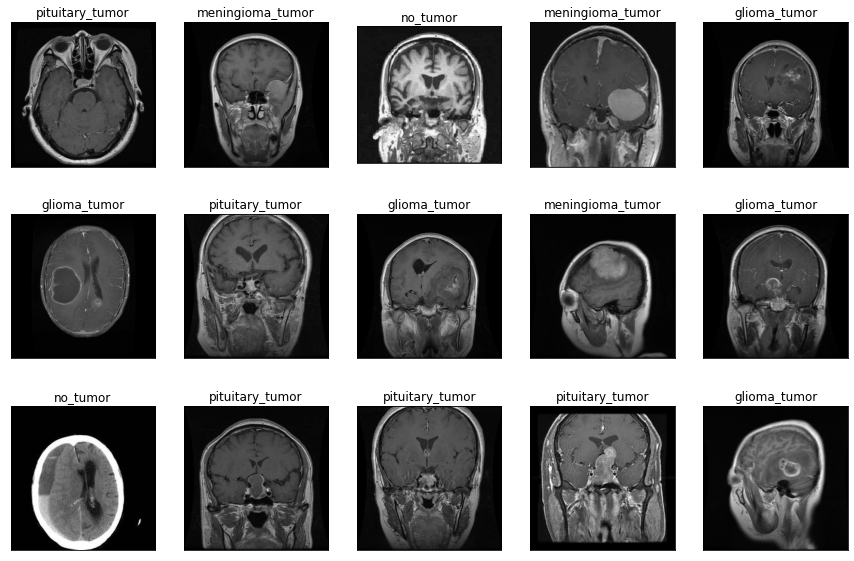

```python
fig, axes = plt.subplots(nrows=3, ncols=5, figsize=(15,10), subplot_kw={'xticks':[], 'yticks':[]})
for i, ax in enumerate(axes.flat):
    ax.imshow(plt.imread(df.Filepaths[i]))
    ax.set_title(df.Labels[i])
plt.show()
```

# Data Splitting & Data Preprocessing:

- The dataset is split into training and testing sets using the train_test_split function from scikit-learn(Separate in train and test data)

```python
train_df, test_df = train_test_split(df, train_size=0.85, shuffle=True, random_state=1)
```

The training set is further divided into a training subset and a validation subset using the validation_split parameter of the ImageDataGenerator.

```python
train_generator = tf.keras.preprocessing.image.ImageDataGenerator(
    preprocessing_function=tf.keras.applications.mobilenet_v2.preprocess_input,
    validation_split=0.15
)

test_generator = tf.keras.preprocessing.image.ImageDataGenerator(
    preprocessing_function=tf.keras.applications.mobilenet_v2.preprocess_input
)
```

```python
train_images = train_generator.flow_from_dataframe(
    dataframe=train_df,
    x_col='Filepaths',
    y_col='Labels',
    target_size=(512, 512),
    color_mode='rgb',
    class_mode='categorical',
    batch_size=4,
    shuffle=True,
    seed=42,
    subset='training'
)
```

```
Found 2772 validated image filenames belonging to 4 classes.
```

```python
val_images = train_generator.flow_from_dataframe(
    dataframe=train_df,
    x_col='Filepaths',
    y_col='Labels',
    target_size=(512, 512),
    color_mode='rgb',
    class_mode='categorical',
    batch_size=4,
    shuffle=True,
    seed=42,
    subset='validation'
)
```

```
Found 489 validated image filenames belonging to 4 classes.
```

```python
test_images = test_generator.flow_from_dataframe(
    dataframe=test_df,
    x_col='Filepaths',
    y_col='Labels',
    target_size=(512, 512),
    color_mode='rgb',
    class_mode='categorical',
    batch_size=4,
    shuffle=False
)
```

```
Found 576 validated image filenames belonging to 4 classes.
```